# Chapter 2 — The Wilcoxon signed-rank test

Comparing two paired or matched biological conditions

**Biostatistics · Molecular Biosciences**  
This chapter introduces wilcoxon signed-rank test using a molecular biosciences experiment. It connects experimental design, statistical reasoning, effect size and R analysis.

## Learning goals

By the end of this chapter, you should be able to:

- recognise paired and matched biological designs
- identify the experimental unit and preserve pairing
- state the null and alternative hypotheses for paired differences
- calculate signed ranks and the test statistic
- distinguish the signed-rank test from the sign test and Mann–Whitney test
- run and interpret the analysis in R

## Biological question: Does treatment change gene expression in the same biological samples?

A researcher measures relative mRNA expression in six independent biological samples before and after antibiotic exposure. Each sample is measured twice: once before treatment (control) and once after treatment. The question is whether expression changes within the same biological samples.

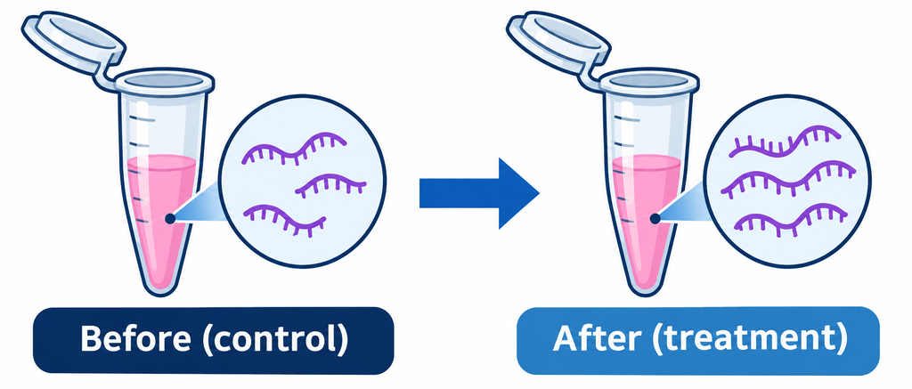

### Experimental unit and replication

Each biological sample is the paired experimental unit. The before and after measurements from one sample are related; they are not independent observations. Technical qPCR replicates are averaged within each biological sample and do not increase the number of biological pairs.

### Before choosing the test

Identify the independent biological unit. Technical replicates improve measurement precision but do not increase the number of independent biological replicates. Preserve pairing or blocking when the same biological unit contributes measurements under multiple conditions.

### What is measured?

Use relative mRNA expression (arbitrary units) measured in the same biological samples before and after antibiotic exposure. Define each paired difference as after minus before, so positive values indicate higher expression after treatment.

## Choosing the method

Use relative mRNA expression (arbitrary units) measured in the same biological samples before and after antibiotic exposure. Define each paired difference as after minus before, so positive values indicate higher expression after treatment.

- Use the Wilcoxon signed-rank test for **two related or paired conditions**.
- Use Mann–Whitney U for **two independent groups**.
- Use the sign test if only the direction of paired differences is to be used, without ranking their magnitudes.

## Assumptions and hypotheses

- Pairs must be meaningfully matched, and pairs must be independent of other pairs.
- The outcome should be at least ordinal; the procedure uses the signs and ranks of paired differences.
- The usual location interpretation assumes the distribution of paired differences is reasonably symmetric around its centre.
- Zero differences are omitted from the signed-rank calculation; ties in absolute differences receive average ranks.
- The test is not simply a test of two independent medians.

Define each paired difference as after minus before, so positive values indicate an increase after treatment.

$$H_0:\ \text{the distribution of paired differences is centred at zero}$$

$$H_1:\ \text{the distribution of paired differences is not centred at zero}$$

For a simple location interpretation, the non-zero paired differences should be reasonably symmetric. The paired observations must remain linked.

## Worked example: data and ranks

Before (control): 0.8, 1.0, 1.1, 1.2, 1.3, 1.4

After (treatment): 1.6, 1.8, 1.9, 2.0, 2.2, 2.4

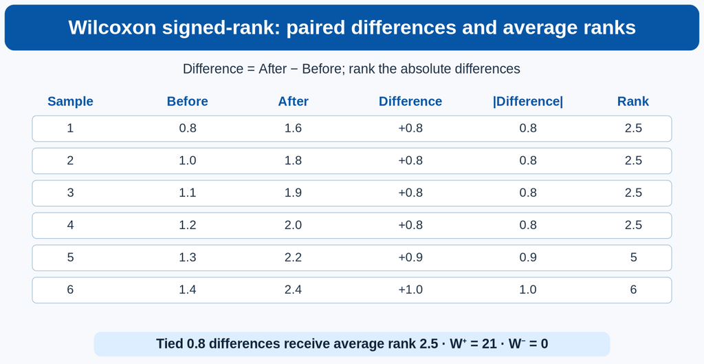

### How the ranks are calculated

The paired differences (after − before) are +0.8, +0.8, +0.8, +0.8, +0.9 and +1.0. The four tied absolute differences of 0.8 receive the average rank 2.5; the ranks for 0.9 and 1.0 are 5 and 6. All differences are positive, so W⁺ = 21 and W⁻ = 0.

$$D_i=X_{i,\mathrm{after}}-X_{i,\mathrm{before}}$$

$$W^+=\sum_{D_i>0}r_i,\qquad W^-=\sum_{D_i<0}r_i$$

The four tied absolute differences of 0.8 receive average rank 2.5; the remaining ranks are 5 and 6. Thus W⁺ = 21 and W⁻ = 0.

## Exact p-value and the null distribution

With six non-zero paired differences and no zero differences, there are 2⁶ = 64 possible sign assignments under the null. All six observed differences are positive, one of the two most extreme outcomes for a two-sided test.

$$p_{\mathrm{two-sided}}=\frac{2}{2^6}=\frac{2}{64}=0.03125$$

Since p = 0.03125 is below 0.05, reject H₀ at the 5% significance level. The exact calculation is suitable for this small sample.

[figure not shown]

The observed W⁺ = 21 is at the upper extreme; the equally extreme lower-tail outcome is W⁺ = 0. Each sign assignment has probability 1/64, so the two-sided p-value is 2/64 = 0.03125.

## Normal approximation

For larger samples, the signed-rank statistic can be approximated by a normal distribution. Under the null hypothesis, its reference distribution has the following expected value and variance:

$$E(W^+)=\frac{n(n+1)}{4}$$

$$\operatorname{Var}(W^+)=\frac{n(n+1)(2n+1)}{24}-\frac{1}{48}\sum_j(t_j^3-t_j)$$

Here, \(n\) is the number of non-zero paired differences and \(t_j\) is the size of each group of tied absolute differences. The second term is the tie correction.

For this example, \(n=6\) and there is one tied group of size 4. Therefore, \(E(W^+)=10.5\) and \(\operatorname{Var}(W^+)=21.5\). With the continuity correction:

$$Z=\frac{21-10.5-0.5}{\sqrt{21.5}}\approx 2.15.$$

R calculates the expected value, variance and tie correction automatically when you use `wilcox.test(after, before, paired = TRUE, exact = FALSE)`. You do not need to calculate them by hand. For this small sample, the exact p-value is preferred; the normal approximation is shown to explain the large-sample option.

## Effect size: method and calculation

Use the **matched-pairs rank-biserial correlation**. It compares the positive and negative signed-rank sums and quantifies the direction and magnitude of the paired rank effect.

$$r_{rb}=\frac{W^+-W^-}{W^++W^-}$$

For this example, W⁺ = 21 and W⁻ = 0:

$$r_{rb}=\frac{21-0}{21+0}=+1$$

The value ranges from −1 to +1. A value of +1 means all non-zero paired differences point in the positive direction; it does not mean a 100% increase. The browser editor preloads a helper function, so the effect size requires only one function call. The browser editor has a small helper function preloaded, so you can calculate this effect size with one function call.

## R practical: run the analysis in your browser

**Editable R code**

Change the data or code, then select Run R.

[output not shown]

## Practice questions

Answer the questions online and check the feedback. These questions are formative: use the explanations to review the relevant sections.

**1. Which design is appropriate for the Wilcoxon signed-rank test?**

- A. Two unrelated groups of cultures
- B. The same cultures measured before and after treatment
- C. Three unrelated treatment groups

**2. What is ranked in the signed-rank procedure?**

- A. The raw measurements pooled across both groups
- B. The absolute non-zero paired differences
- C. The signed differences without taking absolute values

**3. A two-sided test gives p = 0.03. Which interpretation is appropriate?**

- A. There is a 3% probability that the null hypothesis is true
- B. Under the null, a result at least this extreme has probability 0.03
- C. The treatment caused a 3% increase

## Practice questions: calculations and p-values

**7. Which observation is the experimental unit in the paired example?**

- A. Each qPCR technical well
- B. Each biological sample with its before/after pair
- C. Each of the twelve measurements treated independently

**8. When are zero paired differences handled in the signed-rank calculation?**

- A. They are ranked as the smallest positive values
- B. They are omitted from the signed-rank calculation
- C. They are counted as negative ranks

**9. What should be reported with the p-value?**

- A. Only the treatment name
- B. The paired summaries and an effect size with its definition
- C. The p-value as a percentage increase

## Practice questions: interpretation and R

**10. What is ranked in the Wilcoxon signed-rank test?**

- A. All raw values from both groups pooled together
- B. The absolute non-zero paired differences
- C. The treatment labels only

**11. What does W⁺ represent?**

- A. Sum of ranks for positive paired differences
- B. Number of biological replicates
- C. Sum of all raw measurements

**12. What does a rank-biserial correlation of +1 indicate?**

- A. A 100% increase in expression
- B. All non-zero paired differences are positive
- C. The null hypothesis has a 100% probability

## Student notes

Use this space to record your interpretation, questions or reminders. Notes are saved locally in the current browser and device; they are not synchronised between devices.

Notes are stored locally in this browser.

## Chapter recap: the complete infographic

Use this infographic to review the biological question, design, assumptions, hypotheses, rank calculation, test statistic, p-value, effect size and interpretation.

[figure not shown]

**End of Chapter 2 · Biostatistics for Molecular Biosciences**